# Disaster Relief Project Part 2

### Polynominial SVM Model Training

```r
# Train the polynomial SVM model
# measure the time too https://www.r-bloggers.com/2017/05/5-ways-to-measure-running-time-of-r-code/

start.time = Sys.time()

#engage new new new automagic...
#automagic failure

#Error : cannot allocate vector of size 22.6 Gb model fit failed for Fold05: degree=1, scale=0.001, C=0.50

svm.model3 <- train(tarp ~ Red + Blue + Green,
                   data = raw.data,
                   method = "svmPoly",
                   preProcess = c("center","scale"),
                   trControl = train.control2,
                   tuneGrid = expand.grid(degree = c(4, 5, 6, 7),
                                          scale = c(1),
                                          C = c(11, 12))
                   )

#try with center and scale.
#try adding tune grid

end.time = Sys.time()

svm.model3.time = end.time - start.time

# Summarize the results
print(svm.model3)
```

```
## Support Vector Machines with Polynomial Kernel
##
## 63241 samples
##     3 predictor
##     2 classes: 'No.Tarp', 'Tarp'
##
## Pre-processing: centered (3), scaled (3)
## Resampling: Cross-Validated (10 fold)
## Summary of sample sizes: 56917, 56916, 56917, 56917, 56917, 56917, ...
## Resampling results across tuning parameters:
##
##   degree  C   Accuracy   Kappa
##   4       11  0.9970114  0.9517419
##   4       12  0.9970114  0.9517624
##   5       11  0.9971063  0.9531167
##   5       12  0.9970905  0.9528790
##   6       11  0.9971379  0.9535712
##   6       12  0.9971537  0.9538480
##   7       11  0.9970905  0.9528899
##   7       12  0.9971221  0.9534060
##
## Tuning parameter 'scale' was held constant at a value of 1
## Accuracy was used to select the optimal model using the largest value.
## The final values used for the model were degree = 6, scale = 1 and C = 12.
```

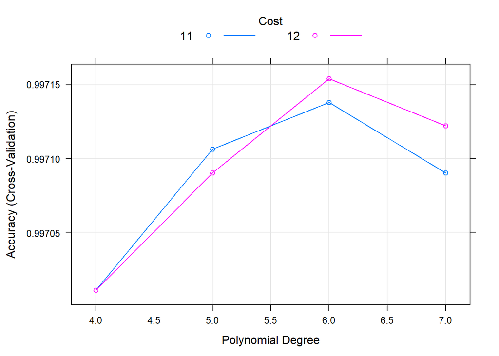

```r
#best accuracy 0.9971 at degree 6, scale 1, Cost 12

#print(svm.model4) checking the scale parameter with other tuning held constant
# scale  Accuracy   Kappa
#  0.5    0.9970431  0.9520167
#  1.0    0.9970747  0.9525250
#  2.0    0.9043713  0.6194096
# leave scale at 1

plot(svm.model3)
```

```r
#plot(svm.model4)

svm.model3$finalModel
```

```
## Support Vector Machine object of class "ksvm"
##
## SV type: C-svc  (classification)
##  parameter : cost C = 12
##
## Polynomial kernel function.
##  Hyperparameters : degree =  6  scale =  1  offset =  1
##
## Number of Support Vectors : 425
##
## Objective Function Value : -4569.404
## Training error : 0.002704
```

```r
#svm.model4$finalModel

svm.model3$bestTune
```

```
##   degree scale  C
## 6      6     1 12
```

```r
#svm.model4$bestTune

final.svm.model3 = svm.model3$pred %>% as_tibble()
```

### Radial SVM Model Analysis and Out of Fold Examination

```r
#the caret object that holds all the magic
#view(final.svm.model2)

cfilter = svm.model2$bestTune$C

svm.Fold1 = final.svm.model2 %>% filter(sigma==svm.model2$bestTune$sigma) %>% filter(C==svm.model2$bestTune$C) %>%  filter(Resample == "Fold01")
svm.Fold2 = final.svm.model2 %>% filter(sigma==svm.model2$bestTune$sigma) %>% filter(C==svm.model2$bestTune$C) %>%  filter(Resample == "Fold02")
svm.Fold3 = final.svm.model2 %>% filter(sigma==svm.model2$bestTune$sigma) %>% filter(C==svm.model2$bestTune$C) %>%  filter(Resample == "Fold03")
svm.Fold4 = final.svm.model2 %>% filter(sigma==svm.model2$bestTune$sigma) %>% filter(C==svm.model2$bestTune$C) %>%  filter(Resample == "Fold04")
svm.Fold5 = final.svm.model2 %>% filter(sigma==svm.model2$bestTune$sigma) %>% filter(C==svm.model2$bestTune$C) %>%  filter(Resample == "Fold05")
svm.Fold6 = final.svm.model2 %>% filter(sigma==svm.model2$bestTune$sigma) %>% filter(C==svm.model2$bestTune$C) %>%  filter(Resample == "Fold06")
svm.Fold7 = final.svm.model2 %>% filter(sigma==svm.model2$bestTune$sigma) %>% filter(C==svm.model2$bestTune$C) %>%  filter(Resample == "Fold07")
svm.Fold8 = final.svm.model2 %>% filter(sigma==svm.model2$bestTune$sigma) %>% filter(C==svm.model2$bestTune$C) %>%  filter(Resample == "Fold08")
svm.Fold9 = final.svm.model2 %>% filter(sigma==svm.model2$bestTune$sigma) %>% filter(C==svm.model2$bestTune$C) %>%  filter(Resample == "Fold09")
svm.Fold10 = final.svm.model2 %>% filter(sigma==svm.model2$bestTune$sigma) %>% filter(C==svm.model2$bestTune$C) %>%  filter(Resample == "Fold10")

# check to see if were getting the fold value/predictions
# xtab.svm.f1 = table(svm.Fold1$pred, svm.Fold1$obs)
# xtab.svm.f1

#Shilpa's awesome/fancy 4-fold plot at threshold of 0.5
fourfoldplot(as.table(table(svm.Fold1$pred, svm.Fold1$obs)),color = c("#E57200", "#232D4B"), conf.level = 0, margin = 1, main = "Confusion Matrix svm.Fold1")

fourfoldplot(as.table(table(svm.Fold2$pred, svm.Fold2$obs)),color = c("#E57200", "#232D4B"), conf.level = 0, margin = 1, main = "Confusion Matrix svm.Fold2")

fourfoldplot(as.table(table(svm.Fold3$pred, svm.Fold3$obs)),color = c("#E57200", "#232D4B"), conf.level = 0, margin = 1, main = "Confusion Matrix svm.Fold3")

fourfoldplot(as.table(table(svm.Fold4$pred, svm.Fold4$obs)),color = c("#E57200", "#232D4B"), conf.level = 0, margin = 1, main = "Confusion Matrix svm.Fold4")

fourfoldplot(as.table(table(svm.Fold5$pred, svm.Fold5$obs)),color = c("#E57200", "#232D4B"), conf.level = 0, margin = 1, main = "Confusion Matrix svm.Fold5")

fourfoldplot(as.table(table(svm.Fold6$pred, svm.Fold6$obs)),color = c("#E57200", "#232D4B"), conf.level = 0, margin = 1, main = "Confusion Matrix svm.Fold6")

fourfoldplot(as.table(table(svm.Fold7$pred, svm.Fold7$obs)),color = c("#E57200", "#232D4B"), conf.level = 0, margin = 1, main = "Confusion Matrix svm.Fold7")

fourfoldplot(as.table(table(svm.Fold8$pred, svm.Fold8$obs)),color = c("#E57200", "#232D4B"), conf.level = 0, margin = 1, main = "Confusion Matrix svm.Fold8")

fourfoldplot(as.table(table(svm.Fold9$pred, svm.Fold9$obs)),color = c("#E57200", "#232D4B"), conf.level = 0, margin = 1, main = "Confusion Matrix svm.Fold9")

fourfoldplot(as.table(table(svm.Fold10$pred, svm.Fold10$obs)),color = c("#E57200", "#232D4B"), conf.level = 0, margin = 1, main = "Confusion Matrix svm.Fold10")

#confusionMatrix uses default threshold of 0.5
svm.cmf1 = confusionMatrix(svm.Fold1$pred, svm.Fold1$obs)
svm.cmf2 = confusionMatrix(svm.Fold2$pred, svm.Fold2$obs)
svm.cmf3 = confusionMatrix(svm.Fold3$pred, svm.Fold3$obs)
svm.cmf4 = confusionMatrix(svm.Fold4$pred, svm.Fold4$obs)
svm.cmf5 = confusionMatrix(svm.Fold5$pred, svm.Fold5$obs)
svm.cmf6 = confusionMatrix(svm.Fold6$pred, svm.Fold6$obs)
svm.cmf7 = confusionMatrix(svm.Fold7$pred, svm.Fold7$obs)
svm.cmf8 = confusionMatrix(svm.Fold8$pred, svm.Fold8$obs)
svm.cmf9 = confusionMatrix(svm.Fold9$pred, svm.Fold9$obs)
svm.cmf10 = confusionMatrix(svm.Fold10$pred, svm.Fold10$obs)

final.svm.model2 = final.svm.model2 %>% filter(sigma==svm.model2$bestTune$sigma) %>% filter(C==svm.model2$bestTune$C)

svm.model.cm = confusionMatrix(final.svm.model2$pred, final.svm.model2$obs)
svm.model.cm
```

```
## Confusion Matrix and Statistics
##
##           Reference
## Prediction No.Tarp  Tarp
##    No.Tarp   61130    75
##    Tarp         89  1947
##
##                Accuracy : 0.9974
##                  95% CI : (0.997, 0.9978)
##     No Information Rate : 0.968
##     P-Value [Acc > NIR] : <2e-16
##
##                   Kappa : 0.9582
##
##  Mcnemar's Test P-Value : 0.31
##
##             Sensitivity : 0.9985
##             Specificity : 0.9629
##          Pos Pred Value : 0.9988
##          Neg Pred Value : 0.9563
##              Prevalence : 0.9680
##          Detection Rate : 0.9666
##    Detection Prevalence : 0.9678
##       Balanced Accuracy : 0.9807
##
##        'Positive' Class : No.Tarp
##
```

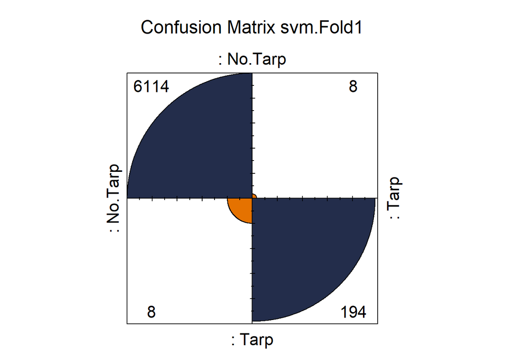

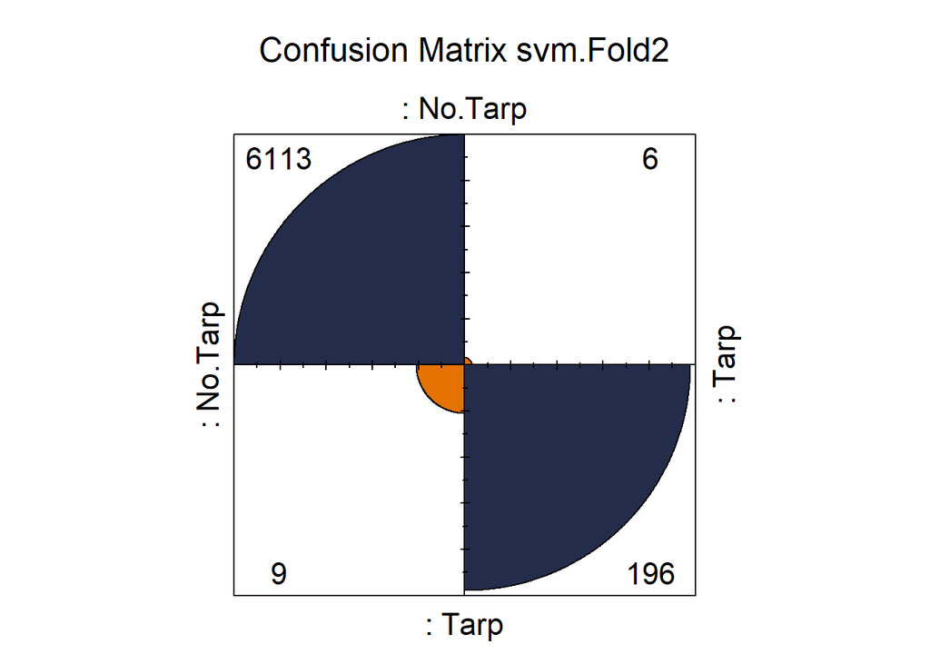

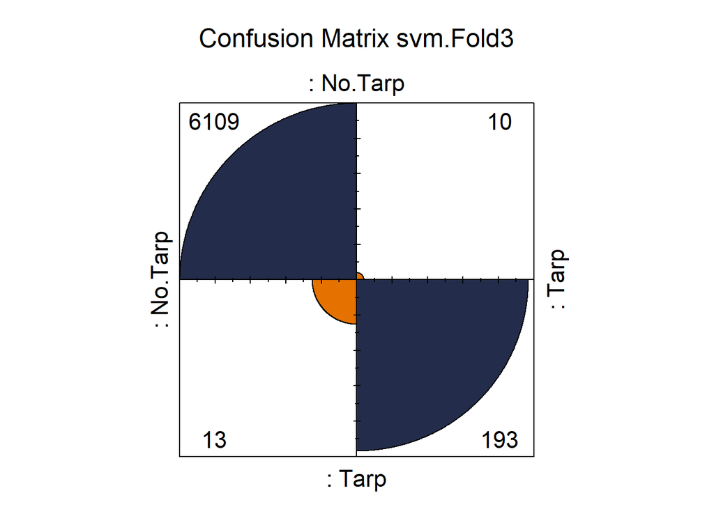

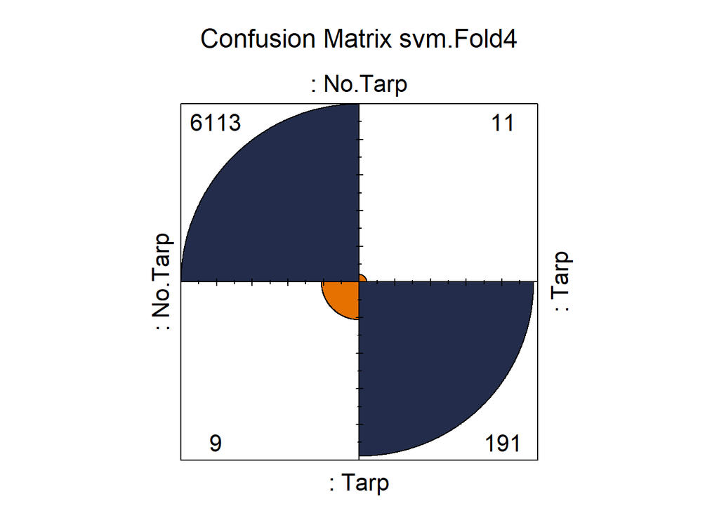

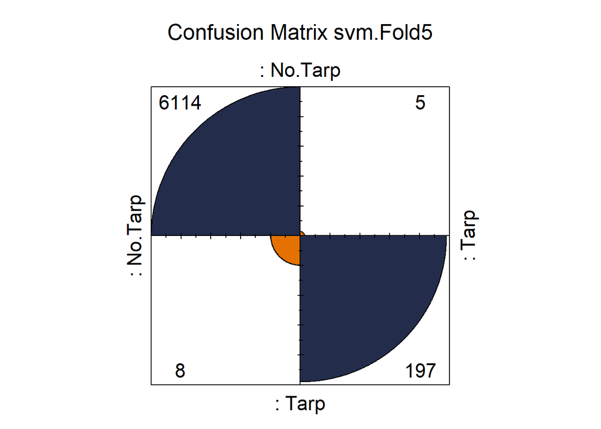

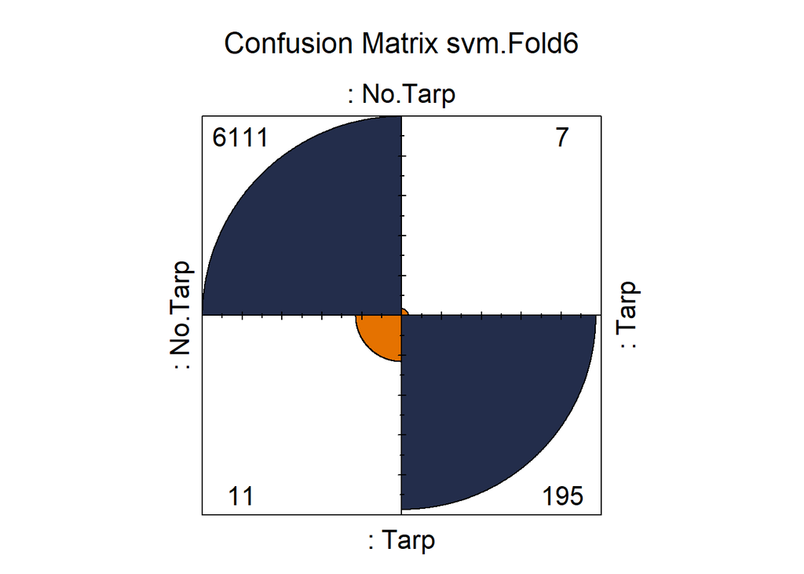

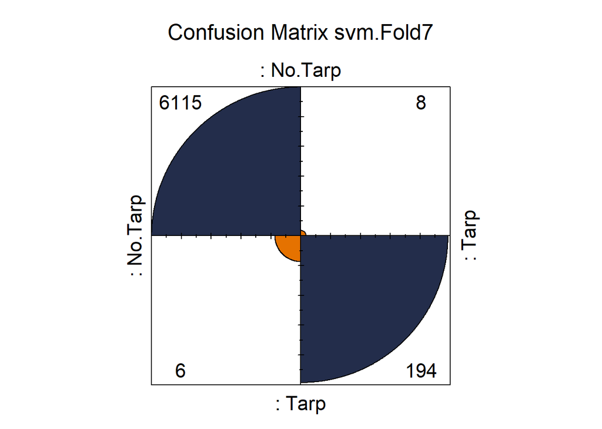

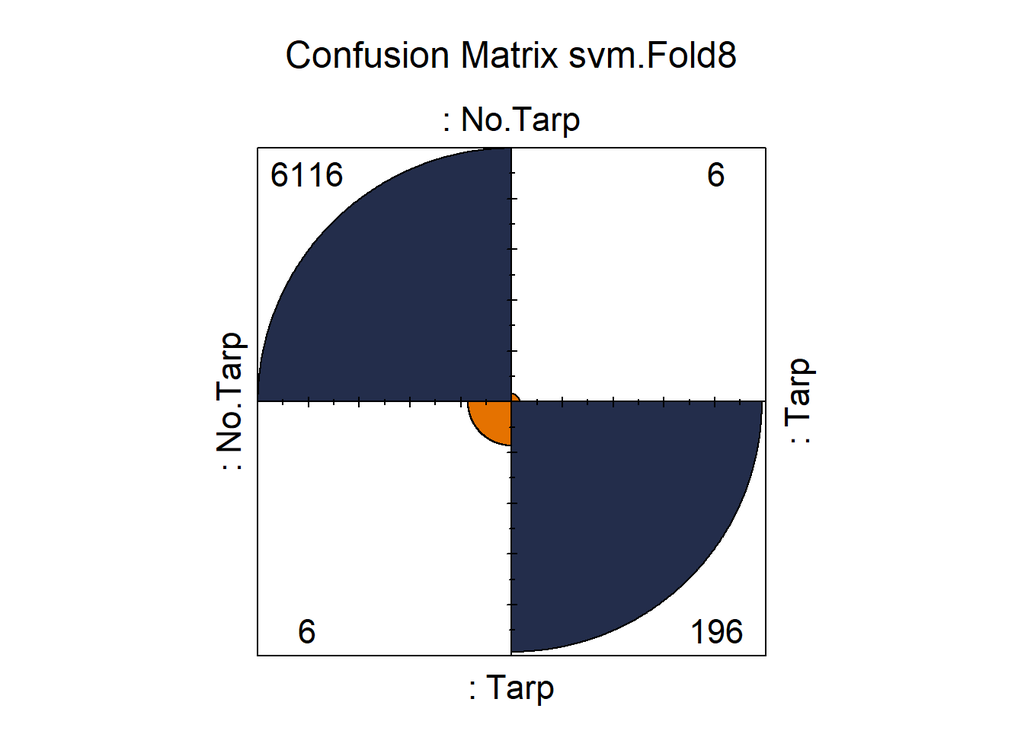

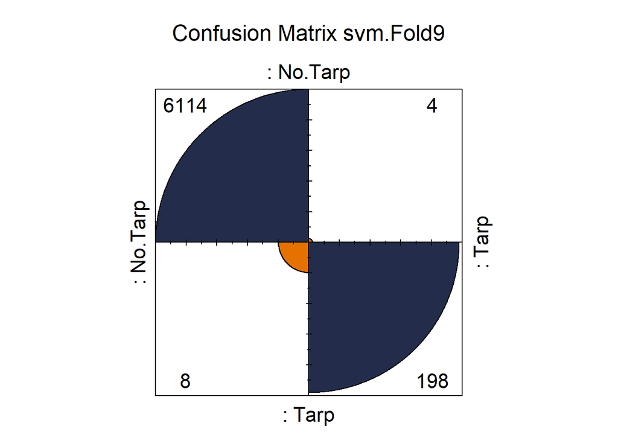

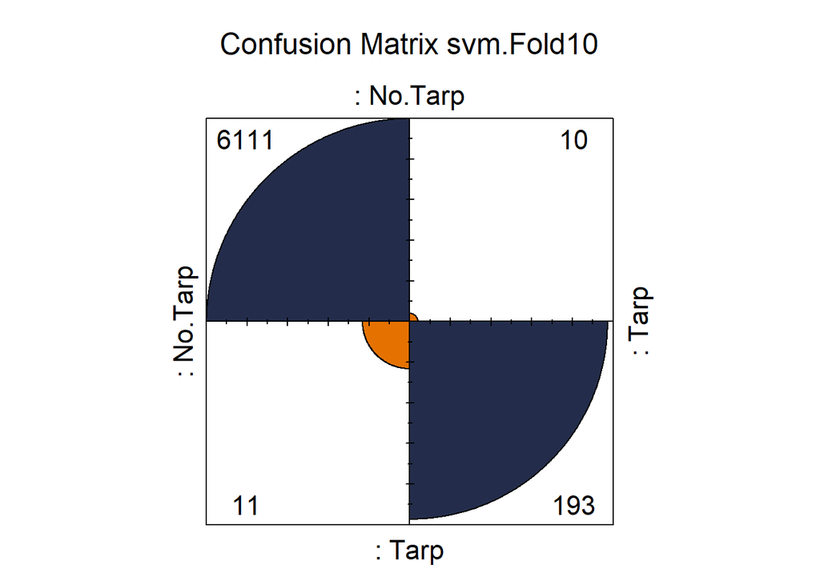

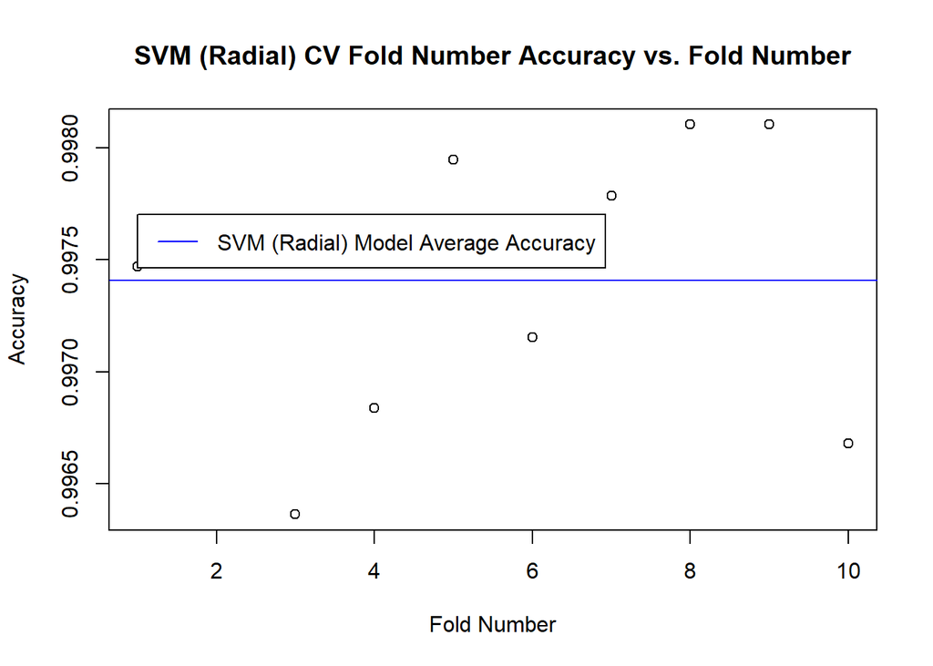

```r
#out of fold accuracy, read in each value
svm.acc.col = c(svm.cmf1$overall[[1]], svm.cmf2$overall[[1]], svm.cmf3$overall[[1]], svm.cmf4$overall[[1]], svm.cmf5$overall[[1]], svm.cmf6$overall[[1]], svm.cmf7$overall[[1]], svm.cmf8$overall[[1]], svm.cmf9$overall[[1]], svm.cmf10$overall[[1]])

svm.acc.calc.cv = mean(svm.acc.col)
svm.acc.calc.oa = svm.model.cm$overall[[1]]

svm.acc.delta.cvoa = svm.acc.calc.cv - svm.acc.calc.oa

plot(fold.num, svm.acc.col, main = "SVM (Radial) CV Fold Number Accuracy vs. Fold Number", ylab = "Accuracy", xlab = "Fold Number") #same fold val from KNN
abline(h=svm.acc.calc.oa, col = "blue")
legend(1, y=0.9977, legend="SVM (Radial) Model Average Accuracy", col ="blue", lty=1)
```

Due to the nature of the SVM model and its method of scoring points to either side of the defined hyperplane and the difficulty of extracting values similar to probabilities using caret, no ROC, AUC or thresholding was conducted. However even without these addition features acceptable accuracy with achieve with this model.

```r
#make a column of the final scores
#cat a line split https://stackoverflow.com/questions/8112786/how-to-split-the-main-title-of-a-plot-in-2-or-more-lines


tuning1 = paste("sigma=", round(svm.model2$bestTune$sigma, 4), sep="")
tuning2 = paste("C=", svm.model2$bestTune$C, sep="")
svm.tuning = paste(tuning1, ", " ,tuning2, sep="")

svm.col = c(round(svm.model.cm$overall[[1]], 4),
            "N/A",
            "N/A",
            "N/A",
            round(svm.model.cm$byClass[[1]], 4),
            round(svm.model.cm$byClass[[2]], 4),
            round((svm.model.cm$table[[3]]/(svm.model.cm$table[[3]]+
                                           svm.model.cm$table[[4]])), 4),
            round((svm.model.cm$table[[1]]/(svm.model.cm$table[[1]]+
                                           svm.model.cm$table[[2]])), 4),
            round(svm.model2.time, 4),
            svm.tuning,
            round(svm.model.cm$overall[[3]], 4),
            round(svm.model.cm$overall[[4]], 4)
            )

table2.df2 = data.frame (Method = method.col, KNN = knn.col, LDA = lda.col, QDA = qda.col, GLM = glm.col, RF = rf.col, SVM = svm.col)

table2.df2 %>% as_tibble
```

```
## # A tibble: 12 x 7
##    Method                   KNN     LDA    QDA    GLM    RF    SVM
##    <chr>                    <chr>   <chr>  <chr>  <chr>  <chr> <chr>
##  1 Accuracy                 0.9947  0.9879 0.9928 0.9905 0.98~ 0.9974
##  2 AUC                      0.9987  0.9889 0.9982 0.9984 0.99~ N/A
##  3 ROC                      Plot    Plot   Plot   Plot   Plot  N/A
##  4 Threshold                0.1     0.005  0.1    0.005  0.03  N/A
##  5 Sensitivity Recall Power 0.9998  1      1      1      1     0.9985
##  6 Specificity 1-FPR        0.8403  0.6222 0.7755 0.7043 0.62~ 0.9629
##  7 FDR                      0.1597  0.3778 0.2245 0.2957 0.37~ 0.0371
##  8 Precision PPV            0.9998  1      1      1      1     0.9985
##  9 Model Running Time (min) 33.7372 0.0193 3e-04  0.0511 1.19~ 1.5884
## 10 Tuning Paramaters        K=9     N/A    N/A    N/A    mtry~ sigma=8.408, C=1~
## 11 CI 95% Lower             0.9941  0.987  0.9921 0.9897 0.987 0.997
## 12 CI 95% Upper             0.9952  0.9887 0.9934 0.9912 0.98~ 0.9978
```

```r
#write csv with same method we used in joining HO data http://www.sthda.com/english/wiki/fast-writing-of-data-from-r-to-txt-csv-files-readr-package

write_csv(table2.df2, file="table2.csv")
```

# Predictions Using Hold Out Data

Predictions were made using a hold out dataset that was assembled from several text files that were provided for this exercise.

```r
HO.data <- read_csv("HOData.csv")
HO.data %>% head() %>% as_tibble()
```

```
## # A tibble: 6 x 4
##   Class      Red  Blue Green
##   <chr>    <dbl> <dbl> <dbl>
## 1 Not.Tarp    68    62    58
## 2 Not.Tarp    65    62    57
## 3 Not.Tarp    65    62    57
## 4 Not.Tarp    64    63    57
## 5 Not.Tarp    72    64    59
## 6 Not.Tarp    72    66    59
```

```r
HO.data %>% summary()
```

```
##     Class                Red             Blue            Green
##  Length:2004177     Min.   : 27.0   Min.   : 25.00   Min.   : 28.0
##  Class :character   1st Qu.: 76.0   1st Qu.: 56.00   1st Qu.: 67.0
##  Mode  :character   Median :107.0   Median : 68.00   Median : 88.0
##                     Mean   :118.3   Mean   : 85.86   Mean   :101.9
##                     3rd Qu.:139.0   3rd Qu.: 96.00   3rd Qu.:113.0
##                     Max.   :255.0   Max.   :255.00   Max.   :255.0
```

## KNN Model Predictions

```r
#test the KNN model on HOData
#make predictions for the KNN Model

start.time = Sys.time()

knn.predict.testHO = predict(knn.model, newdata = HO.data, type = "prob")

end.time = Sys.time()

knn.predict.time = end.time - start.time

#xtab.knn.predict.testHO = table(knn.predict.testHO, HO.data$Class)
#xtab.knn.predict.testHO

# #confusionMatrix wants factors for classifier
# confusionMatrix(knn.predict.testHO, h.data.testHO$tarp)
#
# #Shilpa's awesome/fancy 4-fold plot
# fourfoldplot(as.table(table(knn.predict.testHO, h.data.testHO$tarp)),color = c("#E57200", "#232D4B"), conf.level = 0, margin = 1, main = "Confusion Matrix at threshold 0.5: KNN h.data.testHO")

#set threshold at 0.1 as we picked in tuning
#manually reset threshold

knn.predict.testHO.thres = ifelse(knn.predict.testHO$"No.Tarp" > 0.1, "Not.Tarp", "Tarp") #write a new factor from the prediction "prob" values

xtab.knn.predict.testHO.thres = table(knn.predict.testHO.thres, HO.data$Class)
xtab.knn.predict.testHO.thres
```

```
##
## knn.predict.testHO.thres Not.Tarp    Tarp
##                 Not.Tarp  1978076    6143
##                 Tarp        11621    8337
```

```
## # A tibble: 1 x 3
##   .metric .estimator .estimate
##   <chr>   <chr>          <dbl>
## 1 roc_auc binary         0.958
```

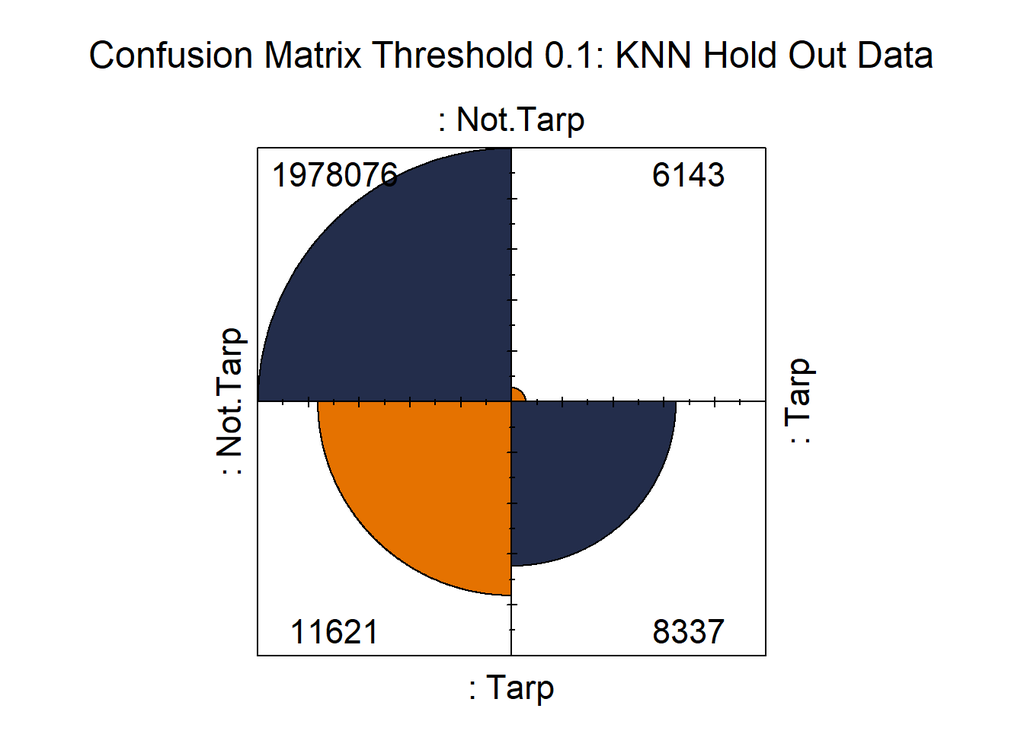

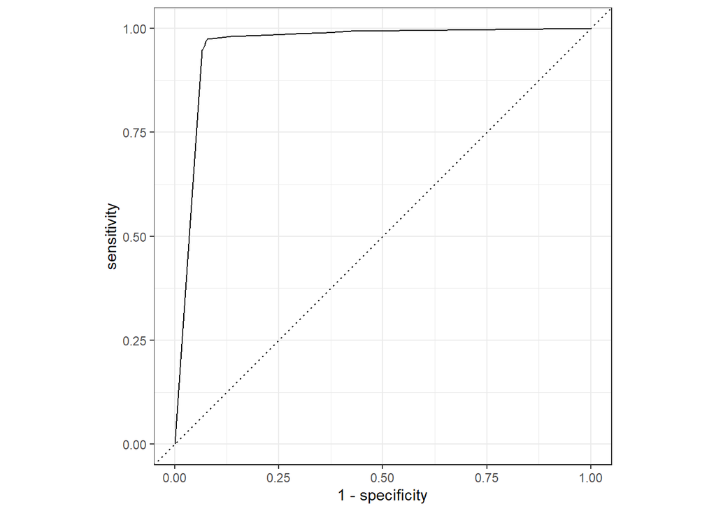

```r
#confusionMatrix feeding it the new threshold data 0.1
knn.predict.cm = confusionMatrix(as.factor(knn.predict.testHO.thres), as.factor(HO.data$Class))

#Shilpa's awesome/fancy 4-fold plot at threshold of 0.1
fourfoldplot(as.table(table(as.factor(knn.predict.testHO.thres), as.factor(HO.data$Class))), color = c("#E57200", "#232D4B"), conf.level = 0, margin = 1, main = "Confusion Matrix Threshold 0.1: KNN Hold Out Data")

#Make ROC and AUC for HOData (KNN)
knn.roc.predict = yardstick::roc_curve(all_of(knn.predict.testHO), "No.Tarp", truth = as.factor(HO.data$Class))

autoplot(knn.roc.predict)

knn.auc.predict = yardstick::roc_auc(all_of(knn.predict.testHO), "No.Tarp", truth = as.factor(HO.data$Class))

knn.auc.predict
```

### KNN Predictions Precsion Recall Curve

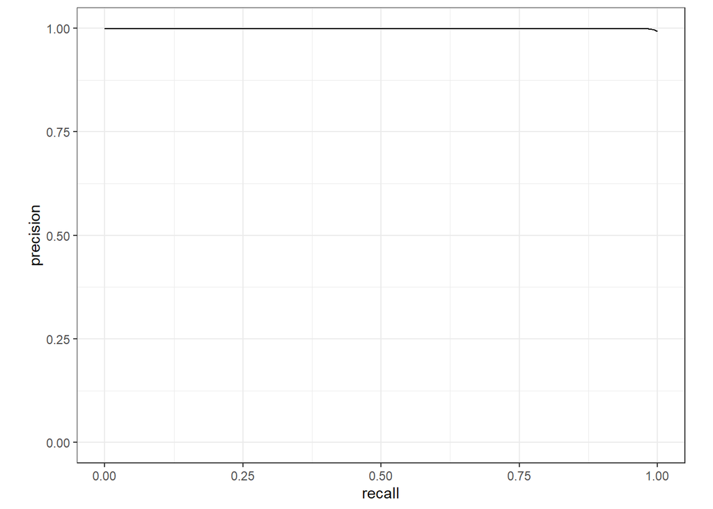

```r
#Make RPC for HOData (KNN)
knn.pr.predict = yardstick::pr_curve(all_of(knn.predict.testHO),
                                      "No.Tarp",
                                      truth = as.factor(HO.data$Class)
                                      )

autoplot(knn.pr.predict)
```